# How Cereal Manufacturers Mislead Consumers?

If you like to eat cereal and pay attention to the nutrition facts, you probably already have been misled. The nutrition displayed on the cereal boxes is measured by serving, which is not a standardized unit. Each manufacturer has its own definition of serving. Further, the same manufacturer can have different definition of serving for different cereals. Therefore, a serving can mean different volume or weight depending on manufacturers and the type of cereal. They are not directly comparable. This makes nutrition facts on cereal boxes hard to understand, and ever misleading.

I asked about 20 people how they measure cereal. It turns out they all measure with volume, for example, by cup, by bowl, by hand, by visual observation, etc. None of them measure cereal by serving or by weight. This analysis compares cereal nutrition measured by serving and by cup, and attempt to work out a meaningful way to compare different cereal nutrition.

```r
library(RCurl)
library(ggplot2)
library(gridExtra)
library(formattable)
```

## Context Notation

**mfr: Manufacturer of cereal**

A = American Home Food Products

G = General Mills

K = Kelloggs

N = Nabisco

P = Post

Q = Quaker Oats

R = Ralston Purina

**type:**

C = Cold

H = Hot

For full notation, see https://www.kaggle.com/crawford/80-cereals

## Loading data

```r
url <- getURL('https://raw.githubusercontent.com/frankwwu/R-Knots/master/80%20Cereals/cereal.csv')
cereals <- read.csv(text = url)
```

## Display data columns and data types

```r
strings <- cereals[1, ]
head(strings)
```

```
##     name         mfr        type calories protein fat sodium fiber carbo
## 1 String Categorical Categorical      Int     Int Int    Int Float Float
##   sugars potass vitamins shelf weight  cups rating
## 1    Int    Int      Int   Int  Float Float  Float
```

```r
cereals = cereals[-1,]
head(cereals)
```

```
##                        name mfr type calories protein fat sodium fiber
## 2                 100% Bran   N    C       70       4   1    130    10
## 3         100% Natural Bran   Q    C      120       3   5     15     2
## 4                  All-Bran   K    C       70       4   1    260     9
## 5 All-Bran with Extra Fiber   K    C       50       4   0    140    14
## 6            Almond Delight   R    C      110       2   2    200     1
## 7   Apple Cinnamon Cheerios   G    C      110       2   2    180   1.5
##   carbo sugars potass vitamins shelf weight cups    rating
## 2     5      6    280       25     3      1 0.33 68.402973
## 3     8      8    135        0     3      1    1 33.983679
## 4     7      5    320       25     3      1 0.33 59.425505
## 5     8      0    330       25     3      1  0.5 93.704912
## 6    14      8     -1       25     3      1 0.75 34.384843
## 7  10.5     10     70       25     1      1 0.75 29.509541
```

## How do manufacturers measure nutrition?

In 7 cereal manufacturers, a serving can mean 7 different weight, or 12 different cups. What a mess! Comparing nutrition by serving alone is pointless!

```r
mfr <- unique(cereals$mfr)
print(paste(length(mfr), 'manufacturers'))
```

```
## [1] "7 manufacturers"
```

```r
print(mfr)
```

```
## [1] N Q K R G P A
## Levels: A Categorical G K N P Q R
```

```r
weight <- unique(cereals$weight)
print(paste(length(weight), 'weight'))
```

```
## [1] "7 weight"
```

```r
print(weight)
```

```
## [1] 1    1.33 1.25 1.3  1.5  0.5  0.83
## Levels: 0.5 0.83 1 1.25 1.3 1.33 1.5 Float
```

```r
cups <- unique(cereals$cups)
print(paste(length(cups), 'cups'))
```

```
## [1] "12 cups"
```

```r
print(cups)
```

```
##  [1] 0.33 1    0.5  0.75 0.67 1.25 0.8  0.88 0.25 1.33 1.5  1.13
## Levels: 0.25 0.33 0.5 0.67 0.75 0.8 0.88 1 1.13 1.25 1.33 1.5 Float
```

## Measure nutrition by serving

Manufacturers like to measure nutrition with serving. Every manufacturer chaotically defines the serving with different weights and cups. Thus, for consumers, comparing nutrition measured with different serving is very confusing in practice. Imagine you are comparing nutrition facts of different cereals in a grocery store and they are measured with different serving, you definitely need a calculator and a piece of paper.

```r
cereals$calories <- as.integer(as.character(cereals$calories))
cereals$protein <- as.integer(as.character(cereals$protein))
cereals$fat <- as.integer(as.character(cereals$fat))
cereals$sodium <- as.integer(as.character(cereals$sodium))
cereals$fiber <- as.numeric(as.character(cereals$fiber))
cereals$carbo <- as.numeric(as.character(cereals$carbo))
cereals$sugars <- as.integer(as.character(cereals$sugars))
cereals$potass <- as.integer(as.character(cereals$potass))
cereals$vitamins <- as.integer(as.character(cereals$vitamins))
cereals$shelf <- as.integer(as.character(cereals$shelf))
cereals$weight <- as.numeric(as.character(cereals$weight))
cereals$cups <- as.numeric(as.character(cereals$cups))
cereals$rating <- as.numeric(as.character(cereals$rating))
```

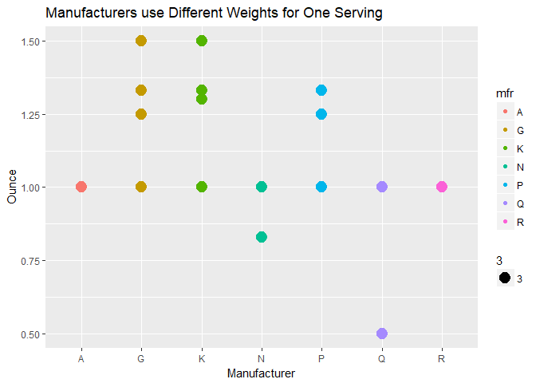

```r
ggplot() +
  geom_point(cereals, mapping=aes(x=mfr, y=weight, color=mfr, size=3)) +
  labs(x="Manufacturer", y="Ounce") +
  ggtitle("Manufacturers use Different Weights for One Serving")
```

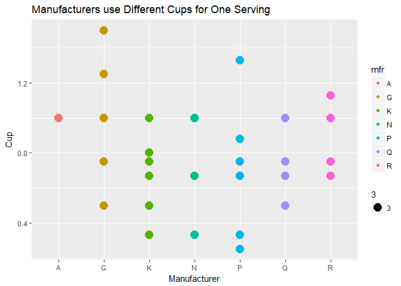

```r
ggplot() +
  geom_point(cereals, mapping=aes(x=mfr, y=cups, color=mfr, size=3)) +
  labs(x="Manufacturer", y="Cup") +
  ggtitle("Manufacturers use Different Cups for One Serving")
```

What the heck does “serving” mean?

## Measure nutrition by cup

Let’s prepare the data to compare some nutrition per serving and per cup.

Convert nutrition to per cup.

```r
# Normalize with cup
cereals.cup <- data.frame(
  name = cereals$name,
  mfr = cereals$mfr,
  type = cereals$type,
  calories= round(as.numeric(cereals$calories) / as.numeric(cereals$cups)),
  protein= round(as.numeric(cereals$protein) / as.numeric(cereals$cups)),
  fat= round(as.numeric(cereals$fat) / as.numeric(cereals$cups)),
  sodium = round(as.numeric(cereals$sodium) / as.numeric(cereals$cups)),
  fiber = round(as.numeric(cereals$fiber) / as.numeric(cereals$cups)),
  carbo = round(as.numeric(cereals$carbo) / as.numeric(cereals$cups)),
  sugars = round(as.numeric(cereals$sugars) / as.numeric(cereals$cups)),
  potass = round(as.numeric(cereals$potass) / as.numeric(cereals$cups)),
  vitamins = round(as.numeric(cereals$vitamins) / as.numeric(cereals$cups)),
  shelf = round(as.numeric(cereals$shelf) / as.numeric(cereals$cups)),
  weight = as.numeric(cereals$weight) / as.numeric(cereals$cups),
  rating = cereals$rating)
```

Comparing nutrition per serving and per cup.

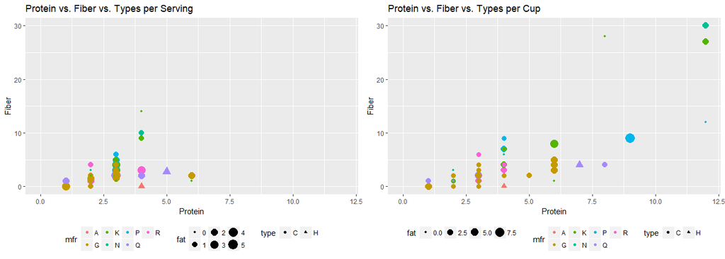

```r
plot_protein_fiber <- function(cereals, xlim, ylim, title){
  ggplot() +
    geom_point(cereals, mapping=aes(x=protein, y=fiber, color=mfr, size=fat, shape=type)) +
    coord_cartesian(xlim=xlim, ylim=ylim) +
    labs(x="Protein", y="Fiber") +
    ggtitle(title) +
    theme(legend.position="bottom")
}

plot1 <- plot_protein_fiber(cereals, c(0, 12), c(0, 30), "Protein vs. Fiber vs. Types per Serving")
plot2 <- plot_protein_fiber(cereals.cup, c(0, 12), c(0, 30), "Protein vs. Fiber vs. Types per Cup")
grid.arrange(plot1, plot2, ncol=2)
```

Calories per serving and per cup are obviously different.

```r
cat("Range of calories per weight:", min(cereals$calories, na.rm = TRUE), "-", max(cereals$calories, na.rm = TRUE), "\n")
```

```
## Range of calories per weight: 50 - 160
```

```r
cat("Range of calories per cup:", min(cereals.cup$calories, na.rm = TRUE), "-", max(cereals.cup$calories, na.rm = TRUE), "\n")
```

```
## Range of calories per cup: 50 - 440
```

Sugar and calories per serving and per cup are very different.

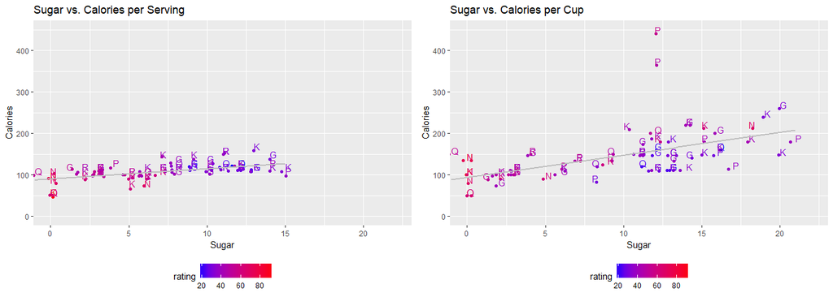

```r
plot_sugars_calories <- function(cereals, xlim, ylim, title){
  ggplot(data=cereals, aes(x=sugars, y=calories, col=rating)) +
    geom_jitter() +
    geom_text(aes(label=mfr),hjust=0, vjust=0) +
    labs(x="Sugar", y="Calories") +
    coord_cartesian(xlim=xlim, ylim=ylim) +
    geom_smooth(method="lm", se=FALSE, col="grey") +
    scale_color_gradient(low="blue", high="red") +
    ggtitle(title) +
    theme(legend.position="bottom")
}

plot1 <- plot_sugars_calories(cereals, c(0, 22), c(0, 450), "Sugar vs. Calories per Serving")
plot2 <- plot_sugars_calories(cereals.cup, c(0, 22), c(0, 450), "Sugar vs. Calories per Cup")
grid.arrange(plot1, plot2, ncol=2)
```

Sugar and sodium per serving and per cup are also different.

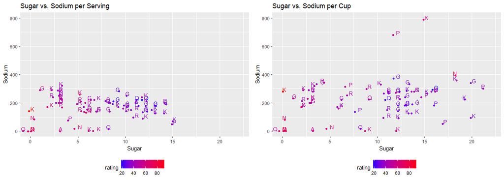

```r
plot_sugars_sodium <- function(cereals, xlim, ylim, title){
  ggplot(data=cereals, aes(x=sugars, y=sodium, col=rating)) +
    geom_jitter() +
    geom_text(aes(label=mfr),hjust=0, vjust=0) +
    labs(x="Sugar", y="Sodium") +
    coord_cartesian(xlim=xlim, ylim=ylim) +
    scale_color_gradient(low="blue", high="red") +
    ggtitle(title) +
    theme(legend.position="bottom")
}

plot1 <- plot_sugars_sodium(cereals, c(0, 22), c(0, 800), "Sugar vs. Sodium per Serving")
plot2 <- plot_sugars_sodium(cereals.cup, c(0, 22), c(0, 800), "Sugar vs. Sodium per Cup")
grid.arrange(plot1, plot2, ncol=2)
```

## Combined nutrition

Let’s combine good and bad nutrition respectively, and examine the difference. For simplicity, no weight is applied to each component.

```r
cereals.per.serving <- data.frame(
  name = cereals$name,
  mfr = cereals$mfr,
  good = cereals$protein + cereals$fiber + cereals$vitamins,
  bad = cereals$fat + cereals$sodium + cereals$potass + cereals$sugars,
  rating = cereals$rating
)

cereals.per.cup <- data.frame(
  name = cereals.cup$name,
  mfr = cereals.cup$mfr,
  good = cereals.cup$protein + cereals.cup$fiber + cereals.cup$vitamins,
  bad = cereals.cup$fat + cereals.cup$sodium + cereals.cup$potass + cereals.cup$sugars,
  rating = cereals$rating
)
```

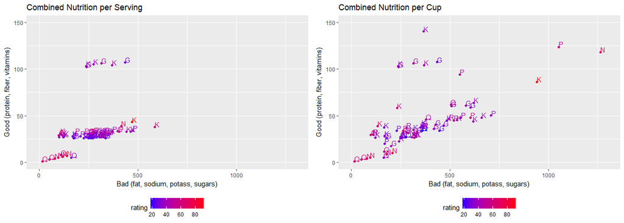

```r
plot_combined <- function(cereals, xlim, ylim, title){
  ggplot(data=cereals, aes(x=bad, y=good, col=rating)) +
    geom_jitter() +
    geom_text(aes(label=mfr),hjust=0, vjust=0) +
    labs(x="Bad (fat, sodium, potass, sugars)", y="Good (protein, fiber, vitamins)") +
    coord_cartesian(xlim=xlim, ylim=ylim) +
    scale_color_gradient(low="blue", high="red") +
    ggtitle(title) +
    theme(legend.position="bottom")
}

plot1 <- plot_combined(cereals.per.serving, c(0, 1300), c(0, 150), "Combined Nutrition per Serving")
plot2 <- plot_combined(cereals.per.cup, c(0, 1300), c(0, 150), "Combined Nutrition per Cup")
grid.arrange(plot1, plot2, ncol=2)
```

## Ranking by combined good nutrition per cup (the higher, the better)

```r
formattable(cereals.per.cup[order(-cereals.per.cup$good),], list(
  good = color_bar("springgreen"),
  bad = color_bar("coral")))
```

|  | name | mfr | good | bad | rating |
| --- | --- | --- | --- | --- | --- |
| 40 | Just Right Fruit & Nut | K | 140 | 367 | 36.47151 |
| 34 | Grape-Nuts | P | 124 | 1052 | 53.37101 |
| 1 | 100% Bran | N | 118 | 1263 | 68.40297 |
| 3 | All-Bran | K | 115 | 1776 | 59.42551 |
| 71 | Total Raisin Bran | G | 107 | 435 | 28.59278 |
| 72 | Total Whole Grain | G | 106 | 314 | 46.65884 |
| 54 | Product 19 | K | 104 | 368 | 41.50354 |
| 39 | Just Right Crunchy Nuggets | K | 103 | 237 | 36.52368 |
| 70 | Total Corn Flakes | G | 102 | 239 | 38.83975 |
| 35 | Great Grains Pecan | P | 94 | 551 | 45.81172 |
| 4 | All-Bran with Extra Fiber | K | 86 | 940 | 93.70491 |
| 20 | Cracklin’ Oat Bran | K | 64 | 620 | 40.44877 |
| 57 | Quaker Oat Squares | Q | 62 | 504 | 49.51187 |
| 60 | Raisin Nut Bran | G | 61 | 580 | 39.70340 |
| 14 | Clusters | G | 60 | 508 | 40.40021 |
| 52 | Oatmeal Raisin Crisp | G | 59 | 604 | 30.45084 |
| 61 | Raisin Squares | K | 58 | 232 | 55.33314 |
| 53 | Post Nat. Raisin Bran | P | 50 | 709 | 37.84059 |
| 10 | Bran Flakes | P | 48 | 604 | 53.31381 |
| 28 | Fruit & Fibre Dates; Walnuts; and Oats | P | 48 | 556 | 40.91705 |
| 29 | Fruitful Bran | K | 48 | 660 | 41.01549 |
| 9 | Bran Chex | R | 46 | 496 | 49.12025 |
| 42 | Life | Q | 46 | 378 | 45.32807 |
| 47 | Mueslix Crispy Blend | K | 45 | 485 | 30.31335 |
| 50 | Nutri-Grain Almond-Raisin | K | 45 | 535 | 40.69232 |
| 75 | Wheat Chex | R | 45 | 520 | 49.78744 |
| 59 | Raisin Bran | K | 44 | 617 | 39.25920 |
| 8 | Basic 4 | G | 40 | 427 | 37.03856 |
| 49 | Nut&Honey Crunch | K | 40 | 358 | 29.92429 |
| 23 | Crispy Wheat & Raisins | G | 39 | 361 | 36.17620 |
| 27 | Frosted Mini-Wheats | K | 39 | 134 | 58.34514 |
| 37 | Honey Nut Cheerios | G | 39 | 467 | 31.07222 |
| 6 | Apple Cinnamon Cheerios | G | 38 | 349 | 29.50954 |
| 5 | Almond Delight | R | 37 | 280 | 34.38484 |
| 24 | Double Chex | R | 37 | 367 | 44.33086 |
| 67 | Smacks | K | 37 | 167 | 31.23005 |
| 77 | Wheaties Honey Gold | G | 37 | 359 | 36.18756 |
| 73 | Triples | G | 36 | 418 | 39.10617 |
| 26 | Frosted Flakes | K | 35 | 315 | 31.43597 |
| 11 | Cap’n’Crunch | Q | 34 | 359 | 18.04285 |
| 13 | Cinnamon Toast Crunch | G | 34 | 356 | 19.82357 |
| 30 | Fruity Pebbles | P | 34 | 230 | 28.02576 |
| 32 | Golden Grahams | G | 34 | 446 | 23.80404 |
| 33 | Grape Nuts Flakes | P | 34 | 263 | 52.07690 |
| 45 | Muesli Raisins; Dates; & Almonds | R | 32 | 279 | 37.13686 |
| 46 | Muesli Raisins; Peaches; & Pecans | R | 32 | 334 | 34.13976 |
| 68 | Special K | K | 32 | 288 | 53.13132 |
| 51 | Nutri-grain Wheat | K | 31 | 262 | 59.64284 |
| 76 | Wheaties | G | 31 | 314 | 51.59219 |
| 31 | Golden Crisp | P | 30 | 113 | 35.25244 |
| 69 | Strawberry Fruit Wheats | N | 30 | 110 | 59.36399 |
| 44 | Maypo | A | 29 | 99 | 54.85092 |
| 48 | Multi-Grain Cheerios | G | 29 | 317 | 40.10596 |
| 7 | Apple Jacks | K | 28 | 169 | 33.17409 |
| 17 | Corn Flakes | K | 28 | 327 | 45.86332 |
| 22 | Crispix | K | 28 | 253 | 46.89564 |
| 25 | Froot Loops | K | 28 | 169 | 32.20758 |
| 12 | Cheerios | G | 27 | 319 | 50.76500 |
| 16 | Corn Chex | R | 27 | 308 | 41.44502 |
| 18 | Corn Pops | K | 27 | 122 | 35.78279 |
| 36 | Honey Graham Ohs | Q | 27 | 278 | 21.87129 |
| 43 | Lucky Charms | G | 27 | 248 | 26.73451 |
| 63 | Rice Krispies | K | 27 | 328 | 40.56016 |
| 15 | Cocoa Puffs | G | 26 | 249 | 22.73645 |
| 19 | Count Chocula | G | 26 | 259 | 22.39651 |
| 74 | Trix | G | 26 | 178 | 27.75330 |
| 62 | Rice Chex | R | 23 | 241 | 41.99893 |
| 38 | Honey-comb | P | 20 | 169 | 28.74241 |
| 41 | Kix | G | 18 | 203 | 39.24111 |
| 58 | Quaker Oatmeal | Q | 11 | 166 | 50.82839 |
| 65 | Shredded Wheat ’n’Bran | N | 10 | 209 | 74.47295 |
| 66 | Shredded Wheat spoon size | N | 8 | 179 | 72.80179 |
| 2 | 100% Natural Bran | Q | 5 | 163 | 33.98368 |
| 64 | Shredded Wheat | N | 5 | 95 | 68.23588 |
| 21 | Cream of Wheat (Quick) | N | 4 | 79 | 64.53382 |
| 56 | Puffed Wheat | Q | 3 | 50 | 63.00565 |
| 55 | Puffed Rice | Q | 1 | 15 | 60.75611 |

## Ranking by combined bad nutrition per cup (the higher, the worse)

```r
formattable(cereals.per.cup[order(-cereals.per.cup$bad),], list(
  good = color_bar("springgreen"),
  bad = color_bar("coral")))
```

|  | name | mfr | good | bad | rating |
| --- | --- | --- | --- | --- | --- |
| 3 | All-Bran | K | 115 | 1776 | 59.42551 |
| 1 | 100% Bran | N | 118 | 1263 | 68.40297 |
| 34 | Grape-Nuts | P | 124 | 1052 | 53.37101 |
| 4 | All-Bran with Extra Fiber | K | 86 | 940 | 93.70491 |
| 53 | Post Nat. Raisin Bran | P | 50 | 709 | 37.84059 |
| 29 | Fruitful Bran | K | 48 | 660 | 41.01549 |
| 20 | Cracklin’ Oat Bran | K | 64 | 620 | 40.44877 |
| 59 | Raisin Bran | K | 44 | 617 | 39.25920 |
| 10 | Bran Flakes | P | 48 | 604 | 53.31381 |
| 52 | Oatmeal Raisin Crisp | G | 59 | 604 | 30.45084 |
| 60 | Raisin Nut Bran | G | 61 | 580 | 39.70340 |
| 28 | Fruit & Fibre Dates; Walnuts; and Oats | P | 48 | 556 | 40.91705 |
| 35 | Great Grains Pecan | P | 94 | 551 | 45.81172 |
| 50 | Nutri-Grain Almond-Raisin | K | 45 | 535 | 40.69232 |
| 75 | Wheat Chex | R | 45 | 520 | 49.78744 |
| 14 | Clusters | G | 60 | 508 | 40.40021 |
| 57 | Quaker Oat Squares | Q | 62 | 504 | 49.51187 |
| 9 | Bran Chex | R | 46 | 496 | 49.12025 |
| 47 | Mueslix Crispy Blend | K | 45 | 485 | 30.31335 |
| 37 | Honey Nut Cheerios | G | 39 | 467 | 31.07222 |
| 32 | Golden Grahams | G | 34 | 446 | 23.80404 |
| 71 | Total Raisin Bran | G | 107 | 435 | 28.59278 |
| 8 | Basic 4 | G | 40 | 427 | 37.03856 |
| 73 | Triples | G | 36 | 418 | 39.10617 |
| 42 | Life | Q | 46 | 378 | 45.32807 |
| 54 | Product 19 | K | 104 | 368 | 41.50354 |
| 24 | Double Chex | R | 37 | 367 | 44.33086 |
| 40 | Just Right Fruit & Nut | K | 140 | 367 | 36.47151 |
| 23 | Crispy Wheat & Raisins | G | 39 | 361 | 36.17620 |
| 11 | Cap’n’Crunch | Q | 34 | 359 | 18.04285 |
| 77 | Wheaties Honey Gold | G | 37 | 359 | 36.18756 |
| 49 | Nut&Honey Crunch | K | 40 | 358 | 29.92429 |
| 13 | Cinnamon Toast Crunch | G | 34 | 356 | 19.82357 |
| 6 | Apple Cinnamon Cheerios | G | 38 | 349 | 29.50954 |
| 46 | Muesli Raisins; Peaches; & Pecans | R | 32 | 334 | 34.13976 |
| 63 | Rice Krispies | K | 27 | 328 | 40.56016 |
| 17 | Corn Flakes | K | 28 | 327 | 45.86332 |
| 12 | Cheerios | G | 27 | 319 | 50.76500 |
| 48 | Multi-Grain Cheerios | G | 29 | 317 | 40.10596 |
| 26 | Frosted Flakes | K | 35 | 315 | 31.43597 |
| 72 | Total Whole Grain | G | 106 | 314 | 46.65884 |
| 76 | Wheaties | G | 31 | 314 | 51.59219 |
| 16 | Corn Chex | R | 27 | 308 | 41.44502 |
| 68 | Special K | K | 32 | 288 | 53.13132 |
| 5 | Almond Delight | R | 37 | 280 | 34.38484 |
| 45 | Muesli Raisins; Dates; & Almonds | R | 32 | 279 | 37.13686 |
| 36 | Honey Graham Ohs | Q | 27 | 278 | 21.87129 |
| 33 | Grape Nuts Flakes | P | 34 | 263 | 52.07690 |
| 51 | Nutri-grain Wheat | K | 31 | 262 | 59.64284 |
| 19 | Count Chocula | G | 26 | 259 | 22.39651 |
| 22 | Crispix | K | 28 | 253 | 46.89564 |
| 15 | Cocoa Puffs | G | 26 | 249 | 22.73645 |
| 43 | Lucky Charms | G | 27 | 248 | 26.73451 |
| 62 | Rice Chex | R | 23 | 241 | 41.99893 |
| 70 | Total Corn Flakes | G | 102 | 239 | 38.83975 |
| 39 | Just Right Crunchy Nuggets | K | 103 | 237 | 36.52368 |
| 61 | Raisin Squares | K | 58 | 232 | 55.33314 |
| 30 | Fruity Pebbles | P | 34 | 230 | 28.02576 |
| 65 | Shredded Wheat ’n’Bran | N | 10 | 209 | 74.47295 |
| 41 | Kix | G | 18 | 203 | 39.24111 |
| 66 | Shredded Wheat spoon size | N | 8 | 179 | 72.80179 |
| 74 | Trix | G | 26 | 178 | 27.75330 |
| 7 | Apple Jacks | K | 28 | 169 | 33.17409 |
| 25 | Froot Loops | K | 28 | 169 | 32.20758 |
| 38 | Honey-comb | P | 20 | 169 | 28.74241 |
| 67 | Smacks | K | 37 | 167 | 31.23005 |
| 58 | Quaker Oatmeal | Q | 11 | 166 | 50.82839 |
| 2 | 100% Natural Bran | Q | 5 | 163 | 33.98368 |
| 27 | Frosted Mini-Wheats | K | 39 | 134 | 58.34514 |
| 18 | Corn Pops | K | 27 | 122 | 35.78279 |
| 31 | Golden Crisp | P | 30 | 113 | 35.25244 |
| 69 | Strawberry Fruit Wheats | N | 30 | 110 | 59.36399 |
| 44 | Maypo | A | 29 | 99 | 54.85092 |
| 64 | Shredded Wheat | N | 5 | 95 | 68.23588 |
| 21 | Cream of Wheat (Quick) | N | 4 | 79 | 64.53382 |
| 56 | Puffed Wheat | Q | 3 | 50 | 63.00565 |
| 55 | Puffed Rice | Q | 1 | 15 | 60.75611 |

## Conclusions

Measuring nutrition by different serving is a mystery. It is almost impossible to quickly compare nutrition facts when you are shopping in a grocery store. Furthermore, the product rating is meaningless for nutrition comparison.